# 24133064_NguyenThiKieuTrang_Exercise1

2026-06-06

A. Lý thuyết

B. Bài tập áp dụng

Câu 1.

Mô phỏng thí nghiệm tung 2 xúc xắc và tính xác suất tổng giá trị 2 xúc xắc bằng 5 hoặc 7. So sánh kết quả thu được với kết quả lý thuyết.

```r
set.seed(123)
n<-1000
xx1 <- sample(1:6, n, replace=TRUE)
xx2 <- sample(1:6, n, replace=TRUE)
tong <- xx1 + xx2

xs_mophong <- mean(tong==5|tong==7)
xs_lythuyet <- 10/36

xs_mophong
```

```
## [1] 0.264
```

```r
xs_lythuyet
```

```
## [1] 0.2777778
```

Câu 2. Giả sử bây giờ ta có 𝑘(𝑘 ≥ 3) cửa thay vì 3 cửa (chỉ một cửa có xe). Hãy viết một hàm thực hiện mô phỏng Monte Carlo cho bài toán Monty Hall với input là 𝑘. Ước lượng xác suất thành công nếu người chơi đổi cửa cho các trường hợp 𝑘 = 5, 𝑘 = 10.

```r
set.seed(123)
monty_hall <- function(k, n=10000){
  win <- 0
  for(i in 1:n){
    doors <- 1:k
    car <- sample(doors,1)
    first_choice <- sample(doors,1)
    if( first_choice!=car){
      win <- win + 1
    }
  }
  return(win/n)
}
result <- data.frame(
  k=c(5,10),
  mo_phong= c(monty_hall(5,10000), monty_hall(10,10000)),
  ly_thuyet=c((5-1)/5,(10-1)/10)
)
result
```

```
##    k mo_phong ly_thuyet
## 1  5   0.8064       0.8
## 2 10   0.9000       0.9
```

Câu 3. Giả sử đội bóng bàn A và B chơi với nhau 7 game. Giả sử đội A có xác suất thắng là 60%. Tính xác suất đội B thắng ít nhất một game.

```r
p <- 1-(0.6)^7
p
```

```
## [1] 0.9720064
```

Câu 4. Thực hiện mô phỏng Monte Carlo để xác nhận câu trả lời lý thuyết của bạn ở câu 3. Sử dụng B <- 10000 thí nghiệm mô phỏng.

```r
set.seed(123)
B <- 10000
dem <- 0
for(i in 1:B){
  result <- sample(c("A","B"), size=7, replace=TRUE, prob=c(0.6, 1-0.6))
  if("B"%in% result){
    dem <- dem + 1
  }
}
xs_mophong <- dem/B
xs_mophong
```

```
## [1] 0.9717
```

Câu 5. Giả sử đội bóng bàn A và B gặp nhau trong một giải đấu. Mỗi trận gồm 7 game, đội nào thắng trước 4 game sẽ thắng trận. Giả sử hai đội có xác suất thắng như nhau. Giả sử đội A thắng game đầu, tính xác suất đội A thắng trận.

```r
21/32
```

```
## [1] 0.65625
```

Câu 6. Thực hiện mô phỏng Monte Carlo để xác nhận câu trả lời lý thuyết của bạn ở câu 5. Sử dụng B <- 10000 thí nghiệm mô phỏng.

```r
set.seed(123)
n <- 10000
A_win <- 0
for(i in 1:n){
  A<-1
  B<-0
  while(A<4 & B<4){
    result <- sample(c("A","B"),1)
    if(result=="A"){
      A<- A+1
    }else{
      B<- B+1
    }
  }
  if(A==4){
    A_win <- A_win+1
  }
}
A_win / n
```

```
## [1] 0.6583
```

Câu 7. Giả sử chiều cao của nữ sinh viên Việt Nam tuân theo phân bố chuẩn với trung bình là 155 cm và độ lệch chuẩn là 10 cm.

1. Nếu chúng ta chọn ngẫu nhiên một sinh viên nữ, thì xác suất cô ấy cao hơn hoặc bằng 170 cm là bao nhiêu?

```r
mean <- 155
sd <- 10
p_a <- 1- pnorm(170, mean=mean, sd=sd)
p_a
```

```
## [1] 0.0668072
```

2. Nếu chúng ta chọn ngẫu nhiên một sinh viên nữ, thì xác suất cô ấy thấp hơn hoặc bằng 150 cm là bao nhiêu?

```r
p_b <- pnorm(150, mean = mean, sd = sd)
p_b
```

```
## [1] 0.3085375
```

3. Nếu chúng ta chọn ngẫu nhiên một sinh viên nữ, thì xác suất cô ấy cao từ 150 cm là đến 160 cm là bao nhiêu?

```r
p_c <- pnorm(160, mean = mean, sd = sd) -
       pnorm(150, mean = mean, sd = sd)

p_c
```

```
## [1] 0.3829249
```

4. Cho biết 1% sinh viên nữ cao nhất co chiều cao bao nhiêu? Gợi ý: sử dụng qnorm.

```r
height_1_percent <- qnorm(0.99, mean = mean, sd = sd)
height_1_percent
```

```
## [1] 178.2635
```

Câu 8. Cho biết chỉ số IQ của người dân tuân theo phân bố chuẩn với trung bình là 100 và độ lệch chuẩn là 15.Giả sử bạn muốn biết sự phân bố của chỉ số IQ cao nhất trên tất cả các độ tuổi nếu mỗi độ tuổi có 10.000người. Thực hiện mô phỏng Monte Carlo với B = 1000 để tạo ra 10.000 điểm IQ và ghi lại điểm cao nhất. Lập biểu đồ tần số để trực quan hóa kết quả.

```r
set.seed(123)
B <- 1000
max_iq <- numeric(B)
for(i in 1:B){
  iq <- rnorm(10000,
              mean = 100,
              sd = 15)

  max_iq[i] <- max(iq)
}
head(max_iq)
```

```
## [1] 157.7165 156.3805 164.8422 159.7417 153.9786 157.4039
```

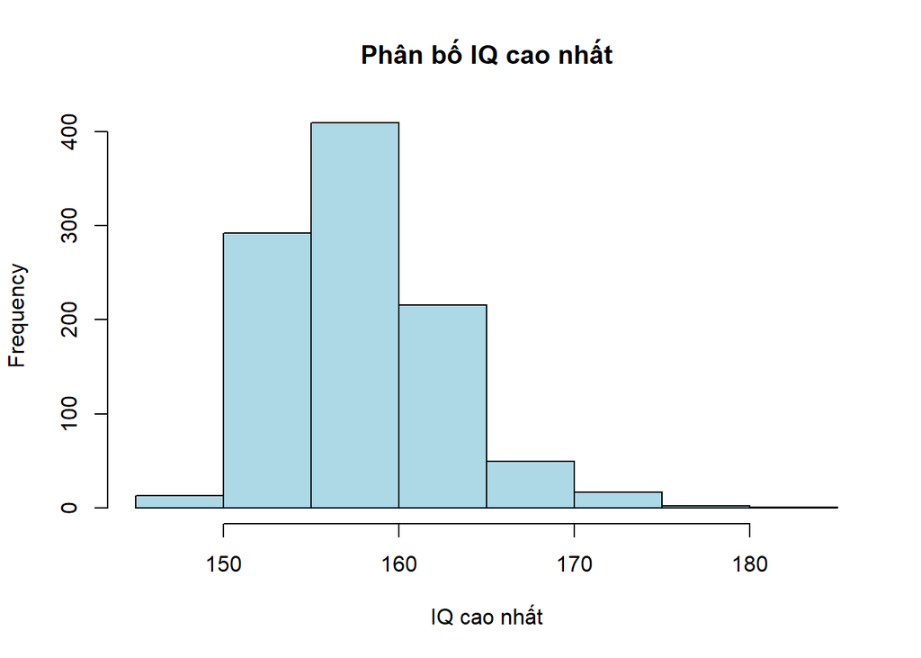

```r
hist(max_iq,
     main = "Phân bố IQ cao nhất",
     xlab = "IQ cao nhất",
     col = "lightblue",
     border = "black")
```